# NESARC Commands

Alan T. Arnholt

February 13, 2015

## Data Management

Start by loading the `PDS` package. If you need directions for installing the `PDS` package, see https://github.com/alanarnholt/PDS.

```r
library(PDS)
```

Create a subset of people 25 or younger who smoked in the last 12 months. To do this, one can use the `dplyr` package. Note that `CHECK321 == 1` is used to see if subject has smoked in the past 12 months and `!is.na()` is used to make sure the subset does not contain `NA`s for the chosen variables.

```r
library(dplyr)
nesarc.sub <- NESARC %>%
  filter(!is.na(CHECK321) & !is.na(AGE) & CHECK321 ==1 & AGE <= 25)
dim(nesarc.sub)
```

```
[1] 1706 3008
```

```r
nesarc.sub <- nesarc.sub %>%
  select(CHECK321, AGE, TAB12MDX, S3AQ3B1, S3AQ3C1, ETHRACE2A, SEX)
dim(nesarc.sub)
```

```
[1] 1706    7
```

```r
summary(nesarc.sub)
```

```
 CHECK321      AGE        TAB12MDX S3AQ3B1     S3AQ3C1     ETHRACE2A
 1:1706   Min.   :18.00   0:810    1:1320   Min.   : 1.0   1:1060
 2:   0   1st Qu.:20.00   1:896    2:  68   1st Qu.: 5.0   2: 211
 9:   0   Median :22.00            3:  91   Median :10.0   3:  42
          Mean   :21.61            4:  88   Mean   :11.8   4:  58
          3rd Qu.:23.00            5:  65   3rd Qu.:20.0   5: 335
          Max.   :25.00            6:  71   Max.   :99.0
                                   9:   3
 SEX
 1:856
 2:850
```

Running `summary` on the `nesarc.sub` reveals some non-obvious categories for the factors (`CHECK321`, `TAB12MDX`, and `S3AQ3B1`). Reviewing the Code Book (HINT: Inside a pdf use `shift F` (Windows) or `command F` (Mac) then type the variable name inside the box to find the variable in the pdf), it is noted that a 9 is used to indicate missing values for `S3AQ3B1` and a 99 is used to indicate missing values for `S3AQ3C1`.

### Coding missing values

The variable `S3AQ3B1` uses a 9 to record `unknown` for smoking frequency and a 99 is used to record `unknown` for `S3AQ3C1`.

```r
nesarc.sub$S3AQ3B1[nesarc.sub$S3AQ3B1 == 9] <- NA
summary(nesarc.sub$S3AQ3B1)  # Note that 9 still appears
```

```
   1    2    3    4    5    6    9 NA's
1320   68   91   88   65   71    0    3
```

```r
nesarc.sub$S3AQ3B1 <- factor(nesarc.sub$S3AQ3B1)[, drop = TRUE]
summary(nesarc.sub$S3AQ3B1)  # Unused level no longer appears
```

```
   1    2    3    4    5    6 NA's
1320   68   91   88   65   71    3
```

```r
nesarc.sub$S3AQ3C1[nesarc.sub$S3AQ3C1 == 99] <- NA
summary(nesarc.sub$S3AQ3C1)
```

```
   Min. 1st Qu.  Median    Mean 3rd Qu.    Max.    NA's
   1.00    5.00   10.00   11.34   20.00   98.00       9
```

```r
summary(nesarc.sub)
```

```
 CHECK321      AGE        TAB12MDX S3AQ3B1        S3AQ3C1      ETHRACE2A
 1:1706   Min.   :18.00   0:810    1   :1320   Min.   : 1.00   1:1060
 2:   0   1st Qu.:20.00   1:896    2   :  68   1st Qu.: 5.00   2: 211
 9:   0   Median :22.00            3   :  91   Median :10.00   3:  42
          Mean   :21.61            4   :  88   Mean   :11.34   4:  58
          3rd Qu.:23.00            5   :  65   3rd Qu.:20.00   5: 335
          Max.   :25.00            6   :  71   Max.   :98.00
                                   NA's:   3   NA's   :9
 SEX
 1:856
 2:850
```

### Creating New Variables

The goal now is to estimate the total number of cigarettes a subject smokes per month. Using the `S3AQ3B1` variable, convert `S3AQ3B1` (a factor with 6 levels) to a numeric variable using `as.numeric`. The new variable `DaysSmoke` estimates the days per month a subject smokes. The variable `TotalCigsSmoked` estimates the monthly number of cigarettes a subject smokes per month by multiplying `DaysSmoke` times `S3AQ3C1` (the usual quantity smoked in a given day).

```r
nesarc.sub$DaysSmoke <- as.numeric(nesarc.sub$S3AQ3B1)
nesarc.sub$DaysSmoke[nesarc.sub$DaysSmoke == 1] <- 30
nesarc.sub$DaysSmoke[nesarc.sub$DaysSmoke == 2] <- 4*5.5
nesarc.sub$DaysSmoke[nesarc.sub$DaysSmoke == 3] <- 4*3.5
nesarc.sub$DaysSmoke[nesarc.sub$DaysSmoke == 4] <- 4*1.5
nesarc.sub$DaysSmoke[nesarc.sub$DaysSmoke == 5] <- 2.5
nesarc.sub$DaysSmoke[nesarc.sub$DaysSmoke == 6] <- 1
# Using dplyr again
nesarc.sub <- nesarc.sub %>%
  mutate(TotalCigsSmoked = DaysSmoke*S3AQ3C1)
proportions <- quantile(nesarc.sub$TotalCigsSmoked, na.rm = TRUE)
proportions
```

```
  0%  25%  50%  75% 100%
   1   90  300  600 2940
```

```r
nesarc.sub$CigsSmokedFac <- cut(nesarc.sub$TotalCigsSmoked, breaks = proportions, include.lowest = TRUE)
head(nesarc.sub)
```

```
  CHECK321 AGE TAB12MDX S3AQ3B1 S3AQ3C1 ETHRACE2A SEX DaysSmoke
1        1  25        1       1       3         2   2        30
2        1  21        1       2       3         5   1        22
3        1  24        1       1      10         1   2        30
4        1  23        1       1      10         1   2        30
5        1  21        0       1      20         1   1        30
6        1  23        0       1       5         1   2        30
  TotalCigsSmoked CigsSmokedFac
1              90        [1,90]
2              66        [1,90]
3             300      (90,300]
4             300      (90,300]
5             600     (300,600]
6             150      (90,300]
```

### Labeling Variables

```r
library(Hmisc)
label(nesarc.sub$TAB12MDX) <- "Tobacco Dependence past 12 Months"
label(nesarc.sub$CHECK321) <- "Smoked Cigarettes in the Past 12 Months"
label(nesarc.sub$S3AQ3B1) <- "Usual Smoking Frequency"
label(nesarc.sub$S3AQ3C1) <- "Usual Smoking Quantity"
nesarc.sub$S3AQ3B1 <- factor(nesarc.sub$S3AQ3B1,
                         labels = c("Every Day", "5 to 6 Days/week",
                                    "3 to 4 Days/week",   "1 to 2 Days/week", "2 to 3 Days/month",
                                    "Once a month or less"))
nesarc.sub$S3AQ3B1 <- factor(nesarc.sub$S3AQ3B1,
                         levels = c("Once a month or less", "2 to 3 Days/month", "1 to 2 Days/week",  "3 to 4 Days/week", "5 to 6 Days/week", "Every Day"))
nesarc.sub$TAB12MDX <- factor(nesarc.sub$TAB12MDX,
                         labels = c("No Nicotine Dependence", "Nicotine Dependence"))
nesarc.sub$TAB12MDX <- factor(nesarc.sub$TAB12MDX,
                         levels = c("Nicotine Dependence", "No Nicotine Dependence"))

table(nesarc.sub$TAB12MDX)
```

```
   Nicotine Dependence No Nicotine Dependence
                   896                    810
```

```r
nesarc.sub$ETHRACE2A <- factor(nesarc.sub$ETHRACE2A, labels = c("Caucasian", "African American", "Native American", "Asian", "Hispanic"))
nesarc.sub$SEX <- factor(nesarc.sub$SEX, labels = c("Male", "Female"))
table(nesarc.sub$SEX)
```

```
  Male Female
   856    850
```

```r
nesarc.sub$SEX <- factor(nesarc.sub$SEX, levels = c("Female", "Male"))
table(nesarc.sub$SEX)
```

```
Female   Male
   850    856
```

### Renaming Variables

```r
nesarc.sub <- nesarc.sub %>%
  rename(TobacoDependence = TAB12MDX, SmokingFreq = S3AQ3B1, DailyCigsSmoked = S3AQ3C1, Ethnicity = ETHRACE2A, Sex = SEX, Age = AGE)
head(nesarc.sub)
```

```
  CHECK321 Age       TobacoDependence      SmokingFreq DailyCigsSmoked
1        1  25    Nicotine Dependence        Every Day               3
2        1  21    Nicotine Dependence 5 to 6 Days/week               3
3        1  24    Nicotine Dependence        Every Day              10
4        1  23    Nicotine Dependence        Every Day              10
5        1  21 No Nicotine Dependence        Every Day              20
6        1  23 No Nicotine Dependence        Every Day               5
         Ethnicity    Sex DaysSmoke TotalCigsSmoked CigsSmokedFac
1 African American Female        30              90        [1,90]
2         Hispanic   Male        22              66        [1,90]
3        Caucasian Female        30             300      (90,300]
4        Caucasian Female        30             300      (90,300]
5        Caucasian   Male        30             600     (300,600]
6        Caucasian Female        30             150      (90,300]
```

### Representing Categorical Data

```r
T1 <- xtabs(~TobacoDependence, data = nesarc.sub)
T1
```

```
TobacoDependence
   Nicotine Dependence No Nicotine Dependence
                   896                    810
```

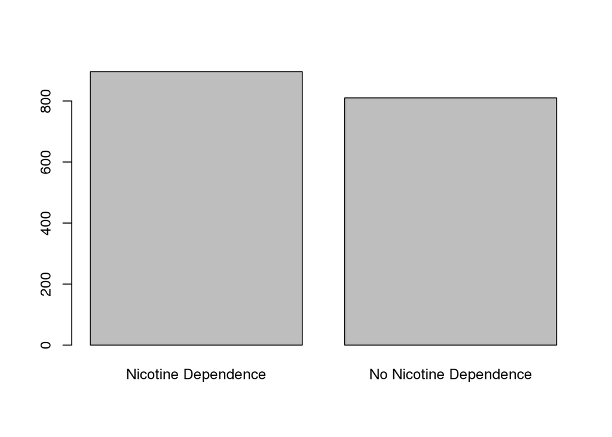

```r
barplot(T1)
```

```r
T2 <- xtabs(~TobacoDependence + SmokingFreq, data = nesarc.sub)
T2
```

```
                        SmokingFreq
TobacoDependence         Once a month or less 2 to 3 Days/month
  Nicotine Dependence                       7                12
  No Nicotine Dependence                   64                53
                        SmokingFreq
TobacoDependence         1 to 2 Days/week 3 to 4 Days/week
  Nicotine Dependence                  19               32
  No Nicotine Dependence               69               59
                        SmokingFreq
TobacoDependence         5 to 6 Days/week Every Day
  Nicotine Dependence                  27       799
  No Nicotine Dependence               41       521
```

```r
PT2 <- prop.table(T2, 2)
PT2
```

```
                        SmokingFreq
TobacoDependence         Once a month or less 2 to 3 Days/month
  Nicotine Dependence              0.09859155        0.18461538
  No Nicotine Dependence           0.90140845        0.81538462
                        SmokingFreq
TobacoDependence         1 to 2 Days/week 3 to 4 Days/week
  Nicotine Dependence          0.21590909       0.35164835
  No Nicotine Dependence       0.78409091       0.64835165
                        SmokingFreq
TobacoDependence         5 to 6 Days/week  Every Day
  Nicotine Dependence          0.39705882 0.60530303
  No Nicotine Dependence       0.60294118 0.39469697
```

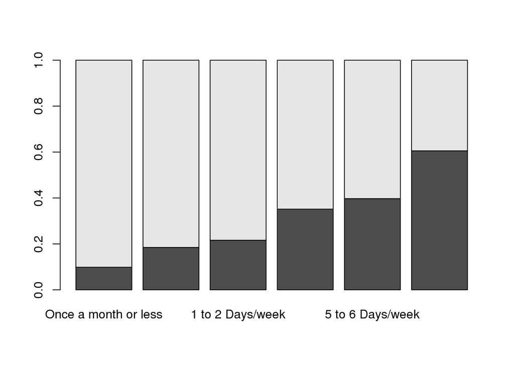

```r
barplot(PT2)
```

Note: Using `na.omit(nesarc.sub)` deletes 9 rows of obervations. If you have many `NA`s in your data frame be very wary of using `na.omit` in this fashion.

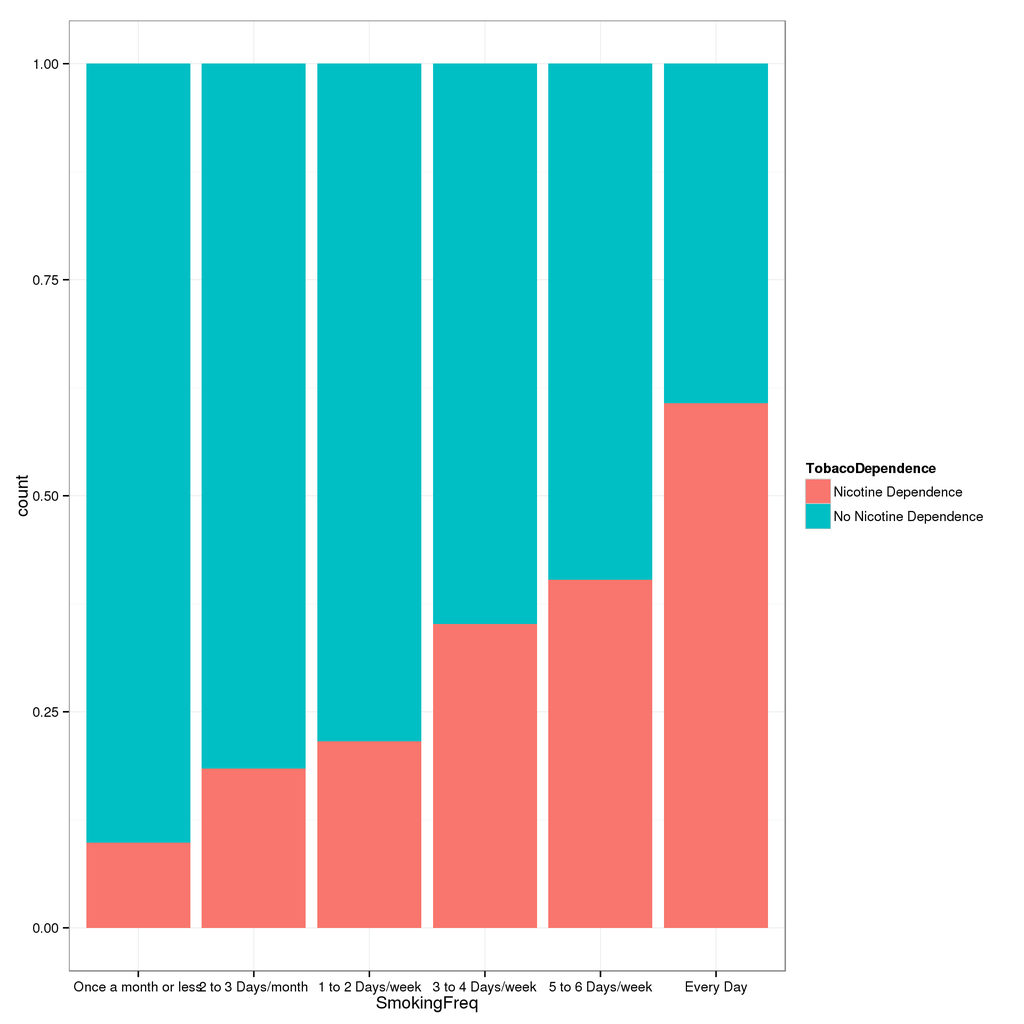

```r
library(ggplot2)
ggplot(data = na.omit(nesarc.sub), aes(x = SmokingFreq, fill = TobacoDependence)) +
  geom_bar(position = "fill") +
  theme_bw()
```

The labels on the `x-axis` of the last graph are overlapping.

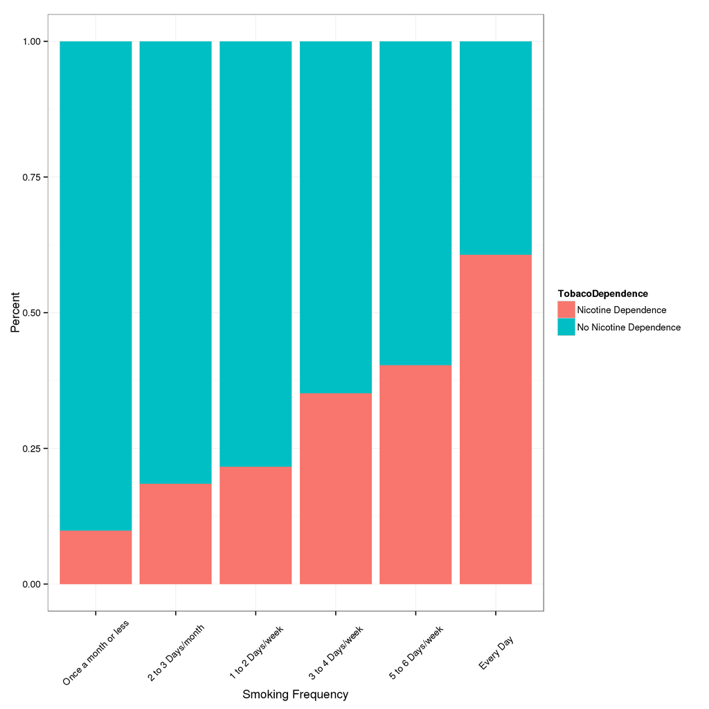

```r
library(ggplot2)
ggplot(data = na.omit(nesarc.sub), aes(x = SmokingFreq, fill = TobacoDependence)) +
  geom_bar(position = "fill") +
  theme_bw() +
  theme(axis.text.x  = element_text(angle = 45, vjust = 0.5)) +
  labs(x = "Smoking Frequency", y = "Percent")
```

Does the relationship hold for different genders?

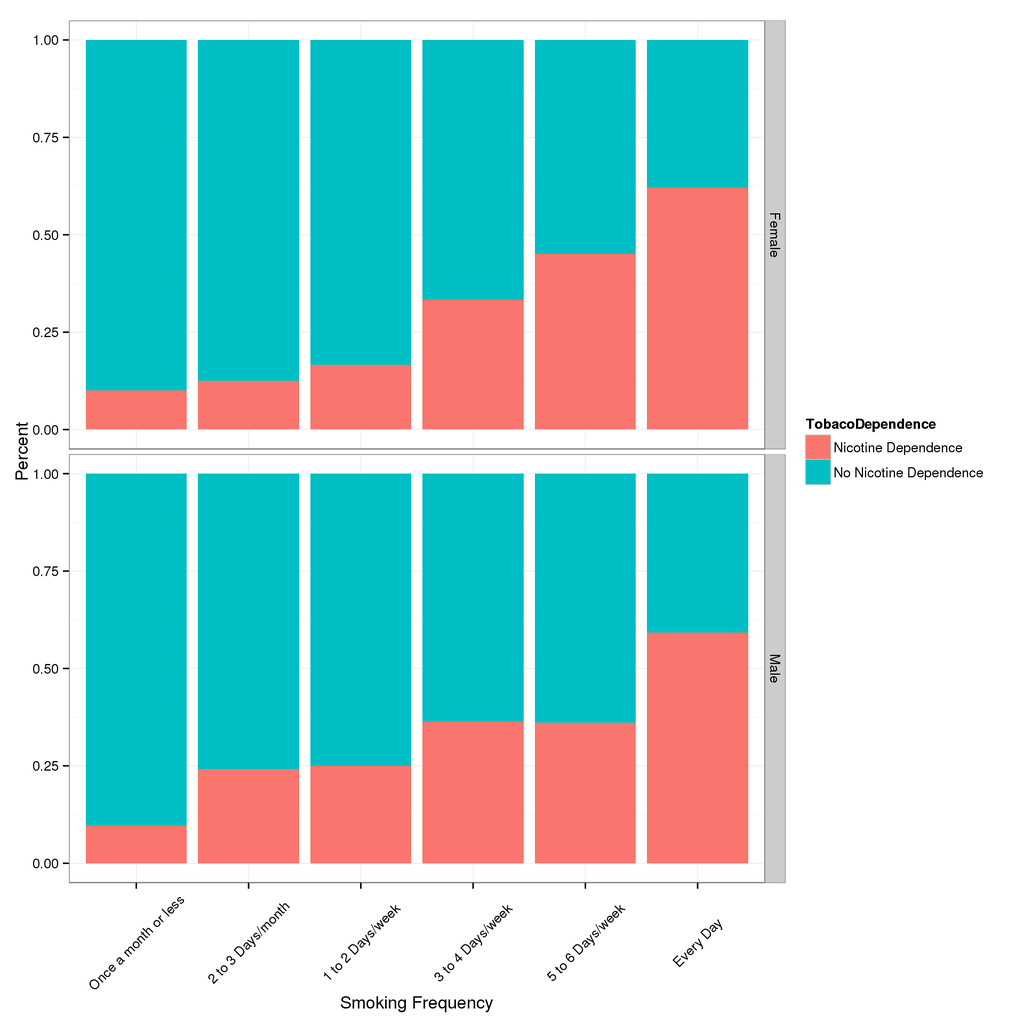

```r
library(ggplot2)
ggplot(data = na.omit(nesarc.sub), aes(x = SmokingFreq, fill = TobacoDependence)) +
  geom_bar(position = "fill") +
  theme_bw() +
  theme(axis.text.x  = element_text(angle = 45, vjust = 0.5)) +
  labs(x = "Smoking Frequency", y = "Percent") +
  facet_grid(Sex ~ .)
```

Does the relationship hold for different ethnicities?

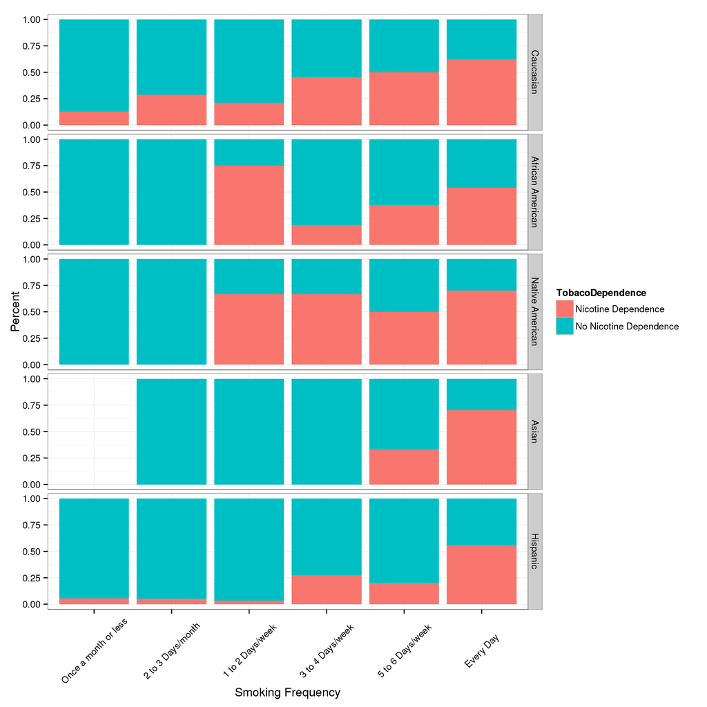

```r
library(ggplot2)
ggplot(data = na.omit(nesarc.sub), aes(x = SmokingFreq, fill = TobacoDependence)) +
  geom_bar(position = "fill") +
  theme_bw() +
  theme(axis.text.x  = element_text(angle = 45, vjust = 0.5)) +
  labs(x = "Smoking Frequency", y = "Percent") +
  facet_grid(Ethnicity ~ .)
```

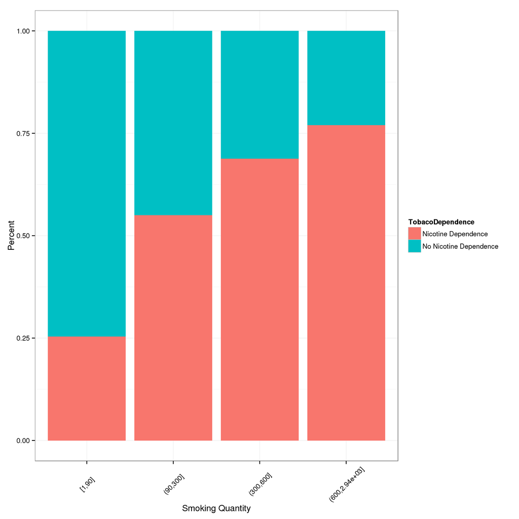

```r
library(ggplot2)
ggplot(data = na.omit(nesarc.sub), aes(x = CigsSmokedFac, fill = TobacoDependence)) +
  geom_bar(position = "fill") +
  theme_bw() +
  theme(axis.text.x  = element_text(angle = 45, vjust = 0.5)) +
  labs(x = "Smoking Quantity", y = "Percent")
```

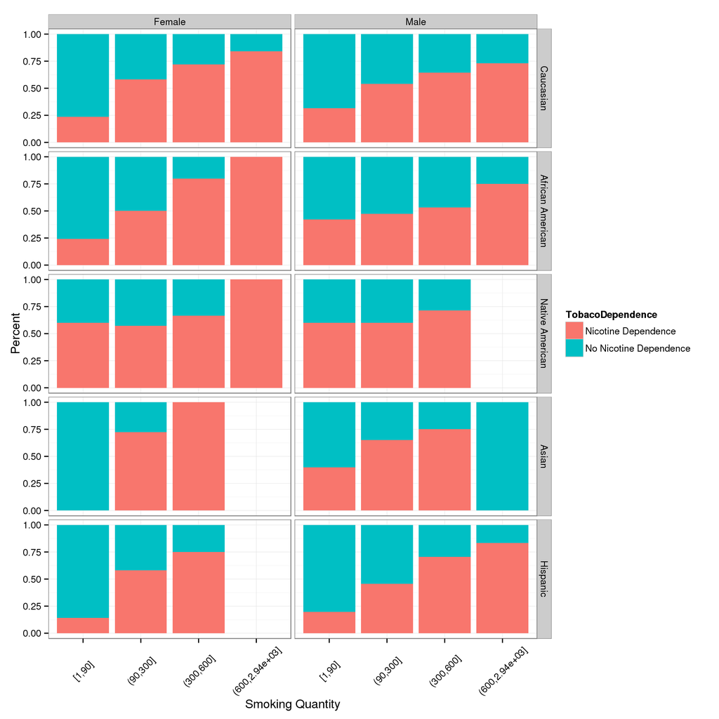

```r
library(ggplot2)
ggplot(data = na.omit(nesarc.sub), aes(x = CigsSmokedFac, fill = TobacoDependence)) +
  geom_bar(position = "fill") +
  theme_bw() +
  theme(axis.text.x  = element_text(angle = 45, vjust = 0.5)) +
  labs(x = "Smoking Quantity", y = "Percent") +
  facet_grid(Ethnicity ~ Sex)
```